# What is Your City's Twin City?

Alkım Can Çelik

20.07.2019

For turkish version, please [click](https://alkimcelik.github.io/Ikiz_Sehirler.html).

## Key Takeaways

- Due to few features, there are 34 matchups which are coupled based on consumption behaviours. To reach all these cities, please click.
- Mostly, results fit general expectations, but there are some surprising results, such as similarity between Eskişehir and Manisa.
- Electricity consumption in industry is the most important factor for determining electricity consumption profile because it varies significantly city by city.
- Population is related to electricity consumption tendency. If industry or agricultural irrigation systems are not developed, it becomes a fundamental factor for determining electricity consumption profile.
- Geographic location and climate play a huge role in determining cities’ electricity consumption profiles. However, these are not key factors. Cities' electricity profiles depend on many factors.

## Introduction

This report has been prepared in order to find which cities are similar to each other in terms of monthly electricity consumption tendency, from January 2017 to April 2019. Reference value is electricity amount billed(faturalanan elektrik miktarı). Data is taken from EPDK(Enerji Piyasası Düzenleme Kurumu).

Codes of this analysis can be reached through this [link](https://alkimcelik.github.io/Codes_Electricity_Consumption_Profiles.html).

There are 4 features for comparison; dwelling, industry, businesses, and agricultural irrigation.

## Preparation

From January 2017 to April 2019, all sector reports published by EPDK were examined. Tables of monthly electricity amount billed have been taken as a reference. Each of them is extracted and combined in one table. Download the data from here [link](http://alkimcelik.github.io/Monthly_Cities_Electricity_Consumptions.rds).

Since metropolises have huge electricity consumption in all features, instead of cities’ electricity consumption quantities, their consumption proportions are used throughout the report. Due to proximity in electricity consumption values and in order to avoid different clustering for the same months, average of electricity consumptions in the same months in different years are taken.

After this, some clustering methods with different approaches are used because certainty of results must be increased. All results are displayed in a similarity matrix(81x81). In this matrix, for each clustering, there are binary indicators. When cities are in the same cluster, intersection of cities in the similarity matrix increases by 1 for each clustering method.

Finally, groups generated by k-means algorithm are classified according to their tendency of electricity consumption. Since there are only a few number of features, cities are divided into only 7 groups. Some clusters include more cities than expected. There might be some surprising results.

## Cities in Clusters

In this section, cities are clustered by using hierarchical method. The dendrogram is shown below. Cities sharing the same color are in the same cluster.

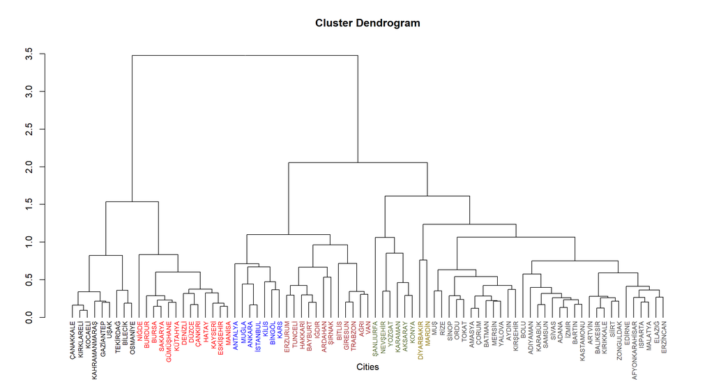

Although there are some surprising results, cities are clustered reasonably. Height of the branches that connect two cities represent similarity between cities’ electricity consumption profiles; the shorter the branches are, the closer the relationship is. For instance, Amasya and Çorum have a very similar electricity consumption profile, as expected. Kırklareli and Kocaeli are also very similar. When İstanbul and Kilis are compared, they have not a very close relationship, however, they are not irrelevant cities surprisingly, because both Kilis and İstanbul have a balanced electricity consumption profile.

Climate is a very important factor in determination of electricity consumption profile, but not the most important as can be seen in the dendrogram. Cities in the same cluster often have similar weather conditions, such as Diyarbakır and Mardin. However, some cities that are in the same climate zone are in different clusters, such as, Antalya and Mersin, because economic activites which are independent from weather conditions in these cities differ from each other. Industrial activities are also very important factors in determining clusters. Its importance is explained in detail below.

## Classification of Clusters

In this section, k-means algorithm is used as clustering method.

Since month by month classification cannot show clear and sufficient results and also, taking average of all months cannot display accurate results, classification is made by taking average of months in the same season. Time periods are seasons.

Nodes indicate sectors’ activities in seasons. Numbers located at top of the leaf nodes indicate which cluster carries out the conditions mostly. Percentages below the group numbers express ratio of clusters’ cities fulfilling conditions. For instance, in brown box, 80 percent of cities carrying out conditions belong to cluster 3, 20 percent belong to cluster 4. The decision tree is below. Since classification needs labels, cities are divided into 7 clusters.

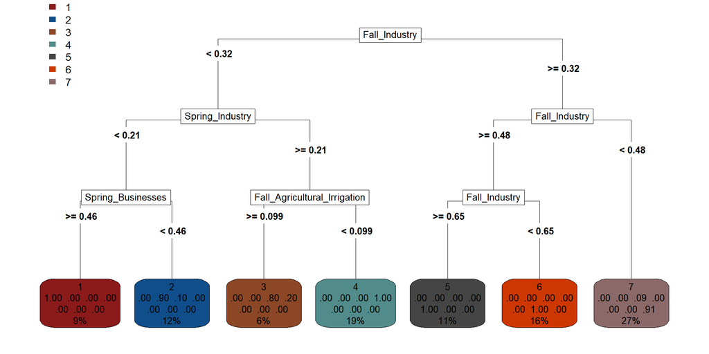

Proportion of electricity consumption in industry(sanayide tüketilen elektrik) is the most principal feature in classification. In industry in fall, 32 percent of consumption is the most certain breakpoint for classification. In general picture, proportion of electricity consumption in industry determines classes where clusters belong to, because industrial activities vary significantly city by city.

Clusters are shown in Turkey map below.

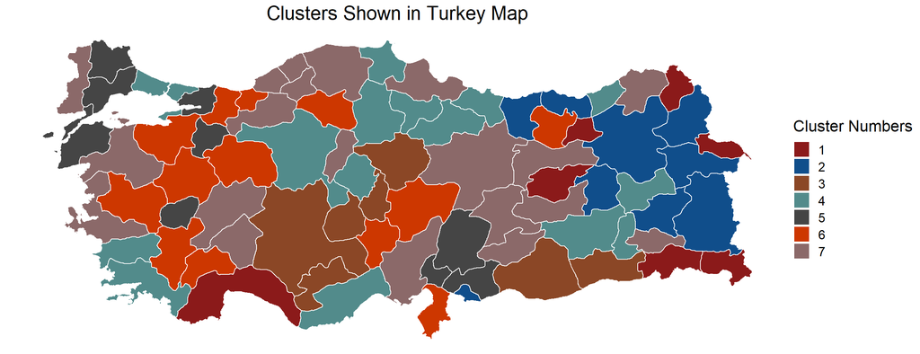

It can be easily noticed that cities in the same cluster having specific characters are located nearby. Especially eastern region of Turkey, due to less improvement in industry, it is more obvious.

In addition to this, cities having developed agricultural irrigation systems are also located nearby and in continental zone. It stems from draught in this region.

Clusters having specific characters are explained in detail below.

### 1) Cluster 5 (Industrial)

```
##          Cities Group_Number
## 1       BILECIK            5
## 2     GAZIANTEP            5
## 3 KAHRAMANMARAS            5
## 4    KIRKLARELI            5
## 5       KOCAELI            5
## 6      OSMANIYE            5
## 7      TEKIRDAG            5
## 8          USAK            5
## 9     ÇANAKKALE            5
```

Cluster 5 has the highest proportion of electricity consumption in industrial activities compared to other clusters. Cities listed above belong to this cluster. Because there are only a few features and clusters, there are some unexpected cities in this cluster, such as Çanakkale and Bilecik. Its reason may be that features except from industry have not much electricity consumption, or in other words, are not effective in this clustering implementation. In industry, electricity consumption is very high, therefore although there may be less employment in industry, proportion of electricity consumption is relatively high compared to other features.

Another reason of surprising results in cluster 5 may be population. Most cities in this cluster have relatively less population. Having small numbers of factories and industrial areas may have enormous impact on electricity consumption in these small cities. Therefore, proportion of electricity consumption in industry could increase easily in small cities if a factory is opened.

### 2) Cluster 3 (Agricultural)

```
##      Cities Group_Number
## 1   AKSARAY            3
## 2   KARAMAN            3
## 3     KONYA            3
## 4    MARDIN            3
## 5  NEVSEHIR            3
## 6    YOZGAT            3
## 7 SANLIURFA            3
```

As interpreted easily from the graph above, cluster 3 has the highest proportion of electricity consumption in agricultural irrigation. The above cities are in this cluster. It can be clearly stated that there is no surprising result, except Yozgat. Yozgat surprisingly satisfies all the conditions. After investigations it is found that, in Yozgat, there is no industrial activity and agricultural activities are common. The other reasons are mentioned below.

When the data is investigated, Diyarbakır also fulfills those conditions, but, because of its other features, it belongs to cluster 4.

Cities in this cluster share many common properties. They are similar in terms of economic activities, and climate conditions. All these cities are in continental climate zone. They share a common problem: drought. They have intensive investments on agriculture and its irrigation.

Proportion of electricity consumption in industry in cluster 3, which is the principal feature, is low compared to other clusters, which increases the proportion of electricity consumption in agricultural irrigation.

### 3) Cluster 1 (Business)

```
##    Cities Group_Number
## 1 ANTALYA            1
## 2 ARDAHAN            1
## 3 BAYBURT            1
## 4 HAKKARI            1
## 5   IGDIR            1
## 6 TUNCELI            1
## 7  SIRNAK            1
```

In this cluster, cities are developed neither in industry nor in agricultural irrigation systems. These cities are not developed in a specific area, except Antalya. Tourism plays a significant role among economic activities in Antalya. Electricity consumption in tourism is categorized as electricity consumption in businesses.

When the populations are investigated, cluster 1 cities have much less population compared to others. They cannot contribute to national economy due to extreme weather conditions, arid lands, and difficulties in transportation. They are consumer cities, not productive.

To sum up, proportion of electricity consumption in businesses in these cities is high compared to other cities.

### 4) Cluster 2 (Dwelling)

```
##    Cities Group_Number
## 1    AGRI            2
## 2  BINGÖL            2
## 3  BITLIS            2
## 4 ERZURUM            2
## 5 GIRESUN            2
## 6    KARS            2
## 7   KILIS            2
## 8 TRABZON            2
## 9     VAN            2
```

In this cluster, like in the business cluster, cities do not have agricultural irrigation systems and industrial activities intensively. However, there is an important factor that distinguishes them, which is population. In this cluster, most cities have more population compared to business cluster. Therefore, proportion of electricity consumption in dwelling in this cluster is higher than the other clusters.

When these cities’ climate conditions are investigated, it can be clearly shown that these cities have a low average temperature. Due to large population and extreme climate conditions, electricity consumption in dwelling tends to be high compared to other cities.

Gap between dwelling cluster and business cluster is very small because their electricity consumption in industry and agricultural irrigation are lower than the other clusters. Also, electricity consumption in businesses and dwelling are related to each other. If one of them is very low, the other one is also very low because of high electricity consumption in industry. Therefore, in section below, there are dual cities with one member from business cluster, the other from dwelling cluster. In addition, most of them are located in eastern region in Turkey.

## Similar Dual Cities

```
##  [1] "AGRI-BAYBURT"            "AGRI-ERZURUM"
##  [3] "BAYBURT-ERZURUM"         "ELAZIG-ERZINCAN"
##  [5] "BURSA-GÜMÜSHANE"         "HAKKARI-IGDIR"
##  [7] "DENIZLI-KAYSERI"         "BILECIK-KIRKLARELI"
##  [9] "BILECIK-KOCAELI"         "KIRKLARELI-KOCAELI"
## [11] "KARAMAN-KONYA"           "ESKISEHIR-MANISA"
## [13] "BILECIK-OSMANIYE"        "KIRKLARELI-OSMANIYE"
## [15] "KOCAELI-OSMANIYE"        "MUS-RIZE"
## [17] "BURSA-SAKARYA"           "GÜMÜSHANE-SAKARYA"
## [19] "ARTVIN-SIIRT"            "BILECIK-TEKIRDAG"
## [21] "KIRKLARELI-TEKIRDAG"     "KOCAELI-TEKIRDAG"
## [23] "OSMANIYE-TEKIRDAG"       "MUS-TOKAT"
## [25] "RIZE-TOKAT"              "ARDAHAN-TUNCELI"
## [27] "KAHRAMANMARAS-USAK"      "TRABZON-VAN"
## [29] "KIRIKKALE-YALOVA"        "KAHRAMANMARAS-ÇANAKKALE"
## [31] "USAK-ÇANAKKALE"          "DÜZCE-ÇANKIRI"
## [33] "AMASYA-ÇORUM"            "ADANA-IZMIR"
```

As indicated in preparation section, dual cities above were obtained with the similarity matrix. These matchups are based on being separated into the same cluster. There are 6 clustering processes with different approaches. These dual cities exist in the same group whenever any clustering method is applied.

It is clearly seen that most cities in dual format have very similar economic activities as expected. For their industrial activities, Kocaeli-Tekirdağ, Kahramanmaraş-Uşak, Bilecik-Osmaniye were matched as dual cities. For their agricultural activities, Karaman-Konya are alike. For business and dwelling, Hakkari-Iğdır, Ağrı-Bayburt, Trabzon-Van, Ardahan-Tunceli are examples for being similar regarding economic activities.

Generally, as expected, most dual cities have either very similar climate conditions or very close populations or both. Therefore, their economic activities resemble each other.

Here are some of the unexpected results: recently in Eskişehir and Manisa, there has been an encouragement for industrial development. Cities’ economic activities tend to be shaped around industry. That is why these cities are matched. Also, in Artvin and Siirt, the populations are very low and industries are not developed. Therefore, their electricity consumption profiles are very similar.

## Conclusion

- Industrial activities and climate conditions are the key factors determining the similarity in electricity consumption between cities.
- Electricity consumption in dwelling and businesses are highly correlated to each other.
- Electricity consumption in agricultural irrigation depends strictly on climate conditions as expected.
- Most of the time, neighboring cities which have very similar climate conditions and close populations share the same electricity consumption profile.

## References

https://www.epdk.org.tr/Detay/Icerik/3-0-23/elektrikaylik-sektor-raporlar

https://rpubs.com/sercandogan/turkeymap

http://www.eskisehir.bel.tr/sayfalar.php?sayfalar_id=15

https://www.egitimsistem.com/manisanin-ekonomik-faaliyetleri-nelerdir-65002h.htm

https://www.turkcebilgi.com/artvin_ekonomisi

http://siirt.bel.tr/tr-tr/alt-sayfalar/198/ekonomi

http://www.cografya.gen.tr/tr/yozgat/ekonomi.html

## About the Author

Alkım Can Çelik is a data science intern who is currently working on analyzing forecasts of electricity distribution companies at Algopoly. He studies Industrial Engineering at Boğaziçi University. He is enthusiastic about data science and analysis, operations research, machine learning algorithms, and finance.

To contact Alkım, you can send an e-mail to alkimcancelik33@gmail.com or through [Linkedin](https://www.linkedin.com/in/alkimcelik-b8446b131/)